# WSR

06 sep 2018

## Inhoud

## Reasoning in statistics

Source: [ARTIST](https://apps3.cehd.umn.edu/artist/glossary.html)

## Statistical Literacy

- Knowledge (Basic understanding of concepts)
  - Identify
  - Describe
- Skils (Ability to work with statistical tools)
  - Translate
  - Interpret
  - Read
  - Compute

## Statistical Reasoning

- Understanding
  - Explain why
  - Explain how

## Statistical thinking

- Apply
  - What methods to use in a specific situation
- Critique
  - Comment and reflect on work of others
- Evaluate
  - Assigning value to work
- Generalize
  - What does variation mean in the large scheme of life

## Empirical Cycle

## By Adriaan de Groot

[interactive chart not shown]

## The components

- Observation
  - Idea for hypothesis
- Induction
  - General rule
  - Hypothesis
- Deduction
  - Expectation / Prediction
  - Operationalization
- Testing
  - Test hypothesis
  - Compare data to prediction
- Evaluation
  - Interpret results in terms of hypothesis

## Explained by Annemarie Zandscholten

[video not shown]

## Null Hypothesis Statistical Significance Testing

Neyman-Pearson Paradigm

## \(H_0\) and \(H_A\)

\(H_0\)

- Skeptical point of view
- No effect
- No preference
- No Correlation
- No difference

\(H_A\)

- Refute Skepticism
- Effect
- Preference
- Correlation
- Difference

## Binomial \(H_0\) distribution

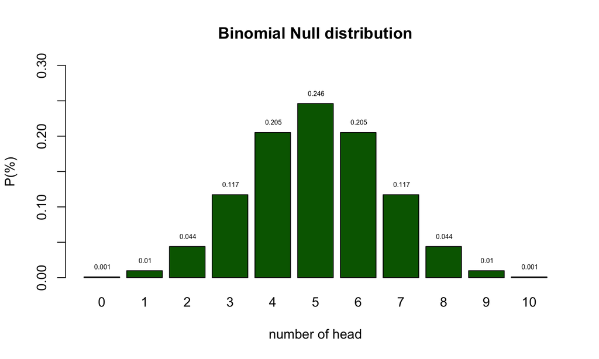

## Binomial \(H_A\) distribution

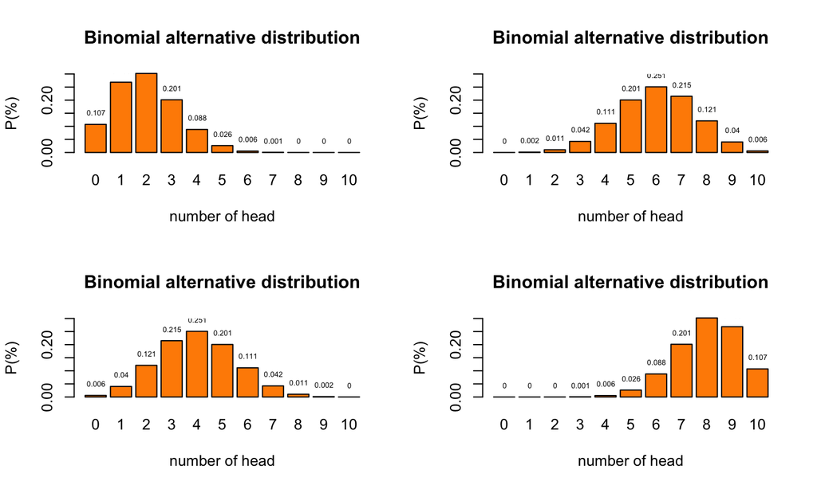

## Decision table

|  | \(H_0\) = True | \(H_0\) = False |
| --- | --- | --- |
| Decide to reject \(H_0\) | Type I error Alpha \(\alpha\) | Correct True positive = Power |
| Decide not to reject \(H_0\) | Correct True negative | Type II error Beta \(\beta\) |

## Alpha \(\alpha\)

- Type I error
- False Positive
- Criteria often 5%
- Distribution depends on sample size

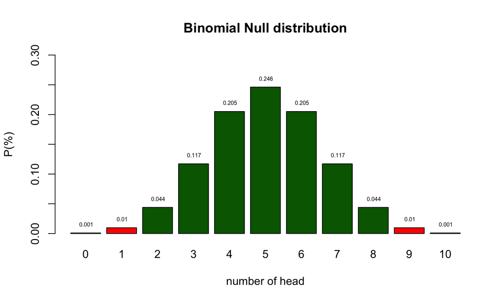

## Power

- True positive
- Power equal to: 1 - Beta
  - Beta is Type II error
- Criteria often 80%
- Depends on sample size

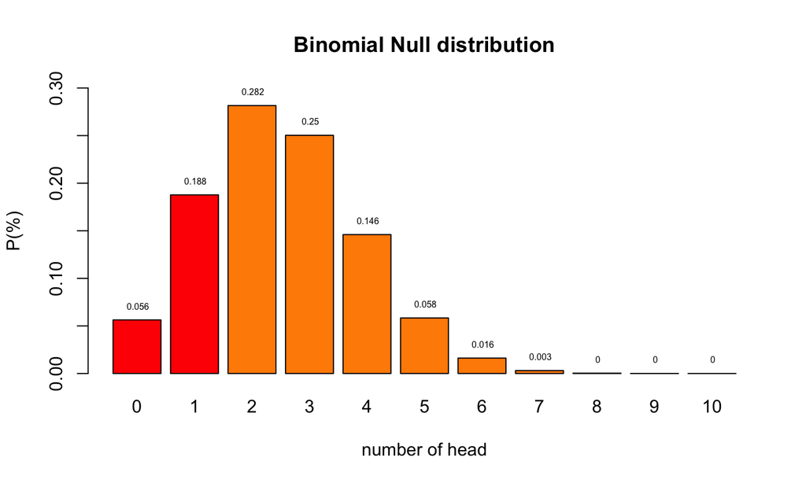

## Post-Hoc Power

- Also known as: observed, retrospective, achieved, prospective and a priori power
- Specificly meaning:

> The power of a test assuming a population effect size equal to the observed effect size in the current sample.

Source: [O'Keefe (2007)](http://www.dokeefe.net/pub/okeefe07cmm-posthoc.pdf)

## 1 - alpha

- True negative

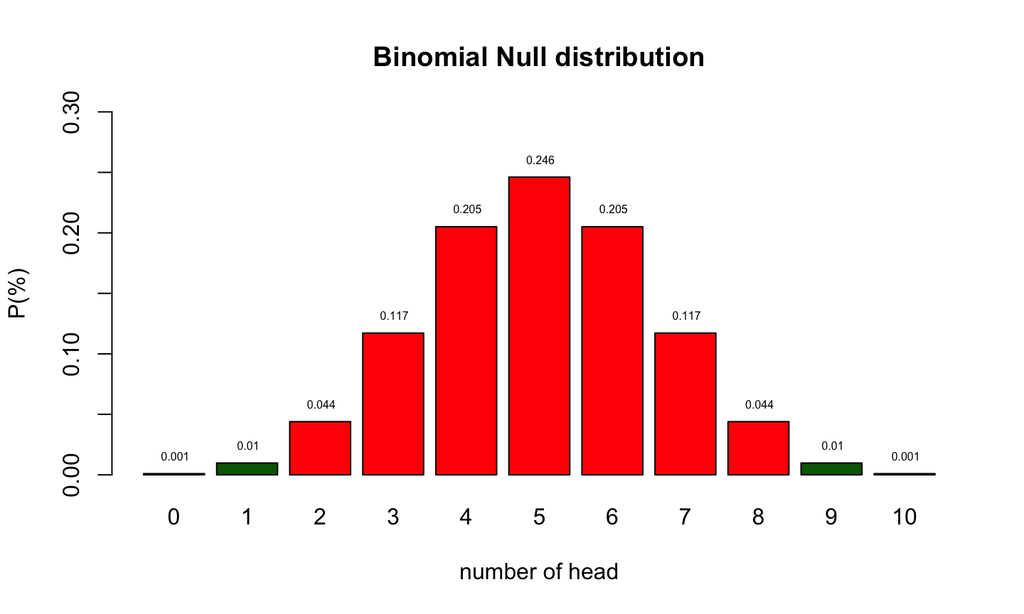

## Beta

- Type II error
- False Negative
- Criteria often 20%
- Distribution depends on sample size

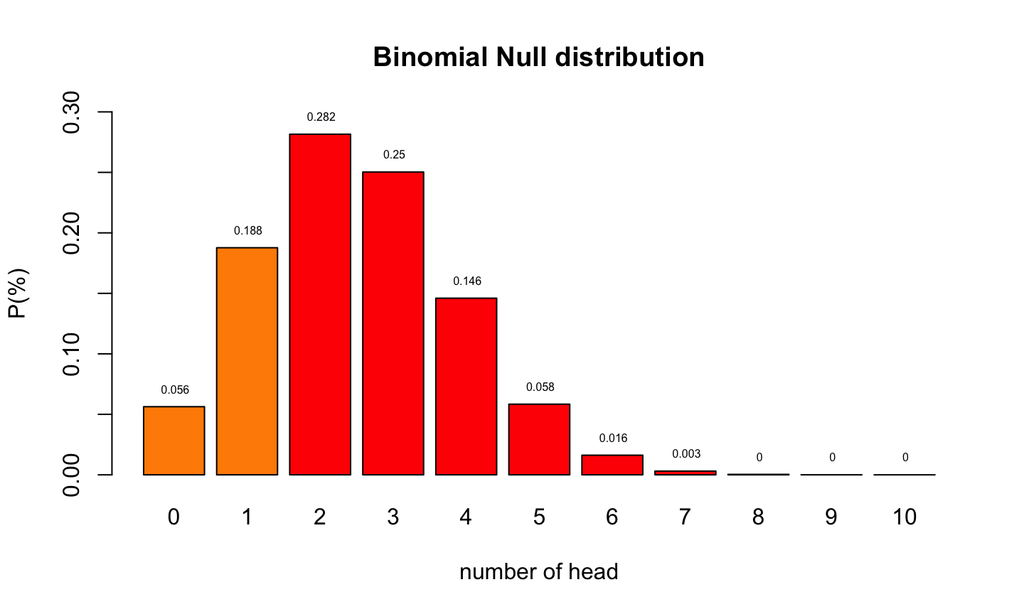

## P-value

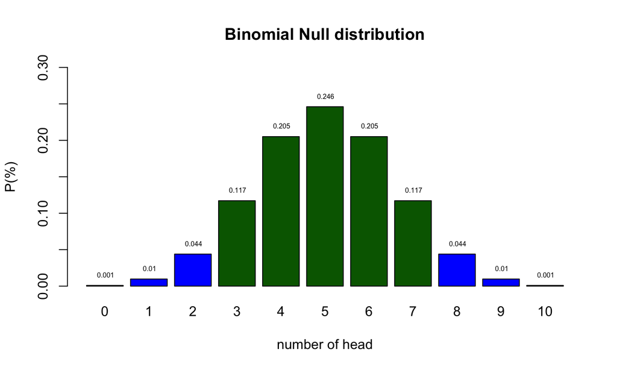

## Modus tollens

Denying the consequent

\[((P\rightarrow{Q})\land\neg{Q})\rightarrow\neg{P}\]

Where \(P\) is a proposition, \(\rightarrow\) means leads to, \(Q\) is the consequence, \(\land\) is a logical and, \(\neg\) means not.

So in words, \(P\) leads to \(Q\), \(Q\) is not true, therefore \(P\) is not true.

- \(P\) states \(H_0\) is TRUE
- Than \(Q\), the test statistic should be equal to the expected value of \(H_0\)
- \(Q\), the test statistic is not equal to EV with a low p-value
- Therefore \(P\), \(H_0\), is rejected

## Fail

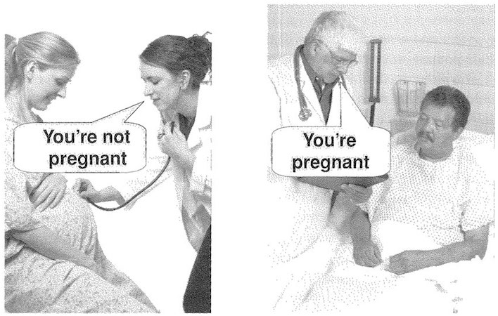

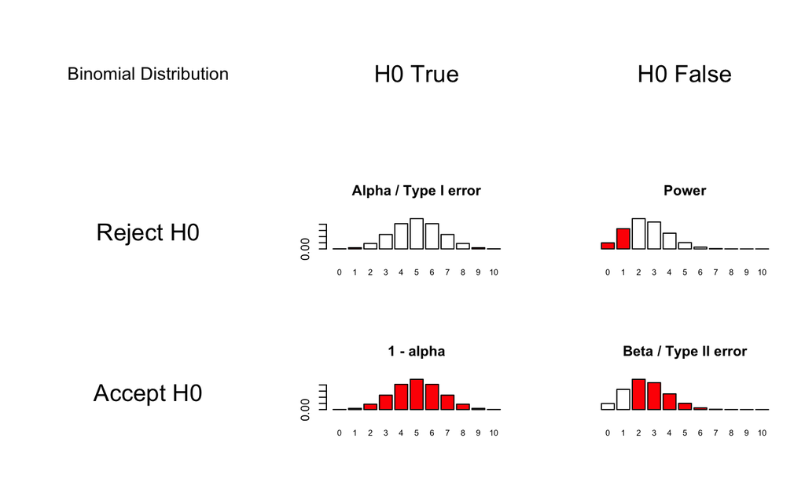

## Standard Error

\[SE = \frac{\text{Standard deviation}}{\text{Square root of sample size}} = \frac{s}{\sqrt{n}}\]

- Lowerbound = \(\bar{x} - 1.96 \times SE\)
- Upperbound = \(\bar{x} + 1.96 \times SE\)

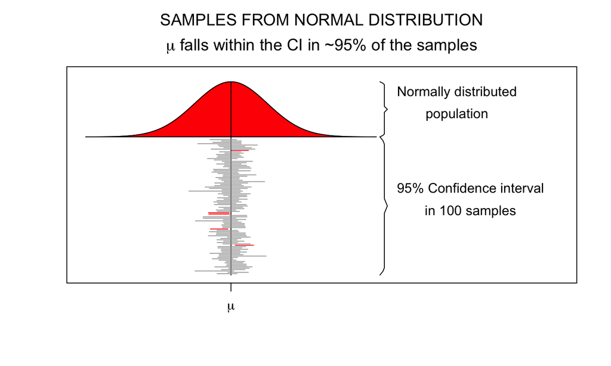

## Standard Error

[interactive chart not shown]

## Reasoning Scheme

[figure not shown]

NHST Reasoning Scheme

## Test statistics

Some common test statistics

- Number of heads
- Sum of dice
- Difference
- \(t\)-statistic
- \(F\)-statistic
- \(\chi^2\)-statistic
- etc…

## Effect size

In statistics, an effect size is a quantitative measure of the strength of a phenomenon.[1] Examples of effect sizes are the correlation between two variables, the regression coefficient in a regression, the mean difference, or even the risk with which something happens, such as how many people survive after a heart attack for every one person that does not survive. For each type of effect size, a larger absolute value always indicates a stronger effect. Effect sizes complement statistical hypothesis testing, and play an important role in power analyses, sample size planning, and in meta-analyses.

Source: [WIKIPEDIA](https://en.wikipedia.org/wiki/Effect_size)

## Effect size

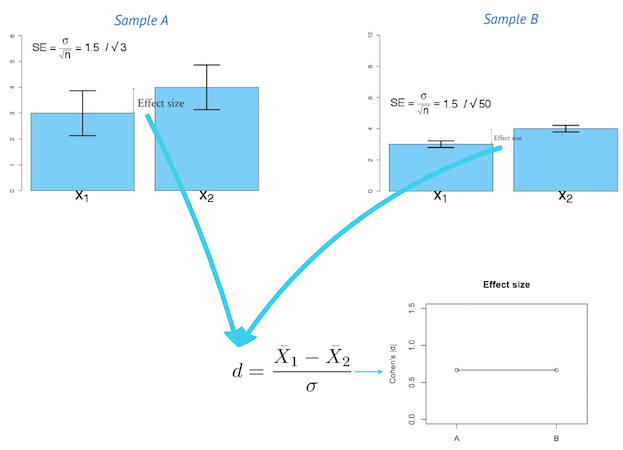

## End

- [@shklinkenberg](https://twitter.com/shklinkenberg)
- [Klinkenberg](https://www.linkedin.com/in/sharonklinkenberg/)
- ln.AvU@grebneknilK.S
- ShKlinkenberg